# Prediction Assignment Project

## Executive Summary

The goal is to use data from accelerometers on the belt, forearm, arm, and dumbell of 6 participants to predict the manner (classe variable) in which they did the exercise. They were asked to perform barbell lifts correctly and incorrectly in 5 different ways. More information is available from the website here: [http://groupware.les.inf.puc-rio.br/har] (see the section on the Weight Lifting Exercise Dataset). RandomForest model is selected to predict classe outcome.

```r
library(caret)
library(ggplot2)
library(Matrix)
## enable caret parallel processing
library(doMC)
registerDoMC(cores=4)
```

#### Data Set

source: [http://groupware.les.inf.puc-rio.br/har]  
The training data for this project are available here:  
[https://d396qusza40orc.cloudfront.net/predmachlearn/pml-training.csv]  
The test data are available here:  
[https://d396qusza40orc.cloudfront.net/predmachlearn/pml-testing.csv]  
We used training dataset to create training (75%) and validation dataset(25%).  
The validation data is used to performance Out of sample error test.

```r
## Get data set from local
trainData <- read.csv("./pml-training.csv", stringsAsFactors = FALSE)
## Training and validation data set
trainInd <- createDataPartition(y=trainData$classe, p=0.75, list=FALSE)
paTrain <- trainData[trainInd,]
paTest <- trainData[-trainInd,]
finalTest <- read.csv("./pml-testing.csv", stringsAsFactors = FALSE)
```

#### Data exploration

```r
dim(paTrain)
```

```
## [1] 14718   160
```

```r
names(paTrain)
```

```
##   [1] "X"                        "user_name"
##   [3] "raw_timestamp_part_1"     "raw_timestamp_part_2"
##   [5] "cvtd_timestamp"           "new_window"
##   [7] "num_window"               "roll_belt"
##   [9] "pitch_belt"               "yaw_belt"
##  [11] "total_accel_belt"         "kurtosis_roll_belt"
##  [13] "kurtosis_picth_belt"      "kurtosis_yaw_belt"
##  [15] "skewness_roll_belt"       "skewness_roll_belt.1"
##  [17] "skewness_yaw_belt"        "max_roll_belt"
##  [19] "max_picth_belt"           "max_yaw_belt"
##  [21] "min_roll_belt"            "min_pitch_belt"
##  [23] "min_yaw_belt"             "amplitude_roll_belt"
##  [25] "amplitude_pitch_belt"     "amplitude_yaw_belt"
##  [27] "var_total_accel_belt"     "avg_roll_belt"
##  [29] "stddev_roll_belt"         "var_roll_belt"
```

[output cut: 65 more lines]

```r
table(paTrain$classe)
```

```
##
##    A    B    C    D    E
## 4185 2848 2567 2412 2706
```

There are 14718 observations and 160 variables in the training data set. The outcome variable “classe” is a factor vector with levels “A”,“B”,“C”,“D”,“E”. It is unrealistic to explore dataset with 159 predictors by visual. I used caret package functions nearZeroVar and find Correlation to select model predictors

#### Data Preparation

I removed irrelevent variables (X, user_name, raw_timestamp_part_1,raw_timestamp_part_2,cvtd_timestamp,new_winds,num_window) to predict outcome from training dataset based on information in source website.

```r
## - Remove irrelevent variables by their descriptions
## X, user_name, raw_timestamp_part_1,raw_timestamp_part_2,cvtd_timestamp,new_winds,num_window
paTrain <- paTrain[,-c(1:7)]
```

I investigated the missing values with predictors and concluded that the predictors either have no missing value or have 14419 missing value of total 14718 obsevations. I decided to remove these predictors have missing value.

```r
## remove none numeric variables except "classe"
classeInd <- which(colnames(paTrain) == "classe")
selNAVar <- colSums(is.na(paTrain))
table(selNAVar)
```

```
## selNAVar
##     0 14419
##    86    67
```

```r
selVar <- sapply(paTrain,function(x){ !any(is.na(x))})
## keep classe column
selVar[classeInd] <- TRUE
paTrain <- paTrain[,selVar]
```

I utilized caret package function nearZeroVar to identify near zero-variance predictors in the dataset and removed them from training dataset. I also filtered highly correlated variables using findCorrelation function to reduce negatively affect to interpretabiliy of model.

```r
## - Remove near zero-variance predictors
nzCol <- nearZeroVar(paTrain,saveMetrics = TRUE)
nzVar <- rownames(nzCol[nzCol$nzv == FALSE,])
paTrain <- subset(paTrain, select =  nzVar)

## - Remove multicollinearity
classeInd <- dim(paTrain)[2]
descrCorr <- cor(paTrain[,-classeInd])
highCorr <- findCorrelation(descrCorr, 0.90)
paTrain <- paTrain[,-highCorr]

dim(paTrain)
```

```
## [1] 14718    46
```

```r
names(paTrain)
```

```
##  [1] "pitch_belt"           "yaw_belt"             "total_accel_belt"
##  [4] "gyros_belt_x"         "gyros_belt_y"         "gyros_belt_z"
##  [7] "magnet_belt_x"        "magnet_belt_y"        "magnet_belt_z"
## [10] "roll_arm"             "pitch_arm"            "yaw_arm"
## [13] "total_accel_arm"      "gyros_arm_y"          "gyros_arm_z"
## [16] "accel_arm_x"          "accel_arm_y"          "accel_arm_z"
## [19] "magnet_arm_x"         "magnet_arm_y"         "magnet_arm_z"
## [22] "roll_dumbbell"        "pitch_dumbbell"       "yaw_dumbbell"
## [25] "total_accel_dumbbell" "gyros_dumbbell_y"     "accel_dumbbell_x"
## [28] "accel_dumbbell_y"     "accel_dumbbell_z"     "magnet_dumbbell_x"
## [31] "magnet_dumbbell_y"    "magnet_dumbbell_z"    "roll_forearm"
## [34] "pitch_forearm"        "yaw_forearm"          "total_accel_forearm"
## [37] "gyros_forearm_x"      "gyros_forearm_y"      "gyros_forearm_z"
## [40] "accel_forearm_x"      "accel_forearm_y"      "accel_forearm_z"
## [43] "magnet_forearm_x"     "magnet_forearm_y"     "magnet_forearm_z"
## [46] "classe"
```

I select randomforest model based on the following major features.  
source:[https://www.stat.berkeley.edu/~breiman/RandomForests/cc_home.htm#features]  
1. It is unexcelled in accuracy among current algorithms.  
2. It runs efficiently on large data set.  
3. It can handle thousands of input variables.  
4. It gives estimates of what variables are importat in the classification.

It narrowed down to 45 predictors to build model after data preparation process.

```r
## set seed
set.seed(19622)
## Building and Tuning model -- RandomForest
rfmodel <- train(classe ~ .,
               data = paTrain, # Use the trainSet dataframe as the training data
               method = "rf",# Use the "random forest" algorithm
               trControl = trainControl(method = "cv", # Use cross-validation
                                        number = 5) # Use 5 folds for cross-validation
)
```

#### Model Performance

```r
##
rfmodel
```

```
## Random Forest
##
## 14718 samples
##    45 predictor
##     5 classes: 'A', 'B', 'C', 'D', 'E'
##
## No pre-processing
## Resampling: Cross-Validated (5 fold)
## Summary of sample sizes: 11774, 11776, 11774, 11773, 11775
## Resampling results across tuning parameters:
##
##   mtry  Accuracy   Kappa      Accuracy SD  Kappa SD
##    2    0.9907601  0.9883106  0.001685670  0.002132363
##   23    0.9916436  0.9894291  0.002418058  0.003058331
##   45    0.9824041  0.9777392  0.005913274  0.007481032
##
## Accuracy was used to select the optimal model using  the largest value.
## The final value used for the model was mtry = 23.
```

K-fold with 5 folds is used for cross-validation. You can see sample sizes for each resampling and their result. mtry is number of predictors randomly sampled to split at each node. mtry value 23 generated the best accuracy and Kappa value. It is chosen as the final model.

#### Predicat the validation samples

```r
## Prediction of new samples -- validation data set
rfPred <- predict(rfmodel,paTest)
table(rfPred)
```

```
## rfPred
##    A    B    C    D    E
## 1397  948  871  790  898
```

#### Out of sample errors and model performance analysis

```r
## out of sample errors
confusionMatrix(rfPred, paTest$classe)
```

```
## Confusion Matrix and Statistics
##
##           Reference
## Prediction    A    B    C    D    E
##          A 1394    3    0    0    0
##          B    1  941    6    0    0
##          C    0    4  849   15    3
##          D    0    1    0  789    0
##          E    0    0    0    0  898
##
## Overall Statistics
##
##                Accuracy : 0.9933
##                  95% CI : (0.9906, 0.9954)
##     No Information Rate : 0.2845
##     P-Value [Acc > NIR] : < 2.2e-16
##
##                   Kappa : 0.9915
##  Mcnemar's Test P-Value : NA
##
## Statistics by Class:
##
##                      Class: A Class: B Class: C Class: D Class: E
## Sensitivity            0.9993   0.9916   0.9930   0.9813   0.9967
## Specificity            0.9991   0.9982   0.9946   0.9998   1.0000
## Pos Pred Value         0.9979   0.9926   0.9747   0.9987   1.0000
## Neg Pred Value         0.9997   0.9980   0.9985   0.9964   0.9993
## Prevalence             0.2845   0.1935   0.1743   0.1639   0.1837
## Detection Rate         0.2843   0.1919   0.1731   0.1609   0.1831
## Detection Prevalence   0.2849   0.1933   0.1776   0.1611   0.1831
## Balanced Accuracy      0.9992   0.9949   0.9938   0.9905   0.9983
```

The summary of confusionMatrix shows that model accuracy is 0.99 (scale 0 to 1, 1 is the best) and Kappa,i.e. precision, is 0.99 (scale 0 to 1, 1 is the best). Overall model performance is great. In outcome classes level, the model prediction performance for class D has the poorest sensitivity(0.9813) and class C has the poorest specificty (0.9946). You can find prediction errors detail from above prefence/prediction table.

#### Ranking the importance of predictors in the classification

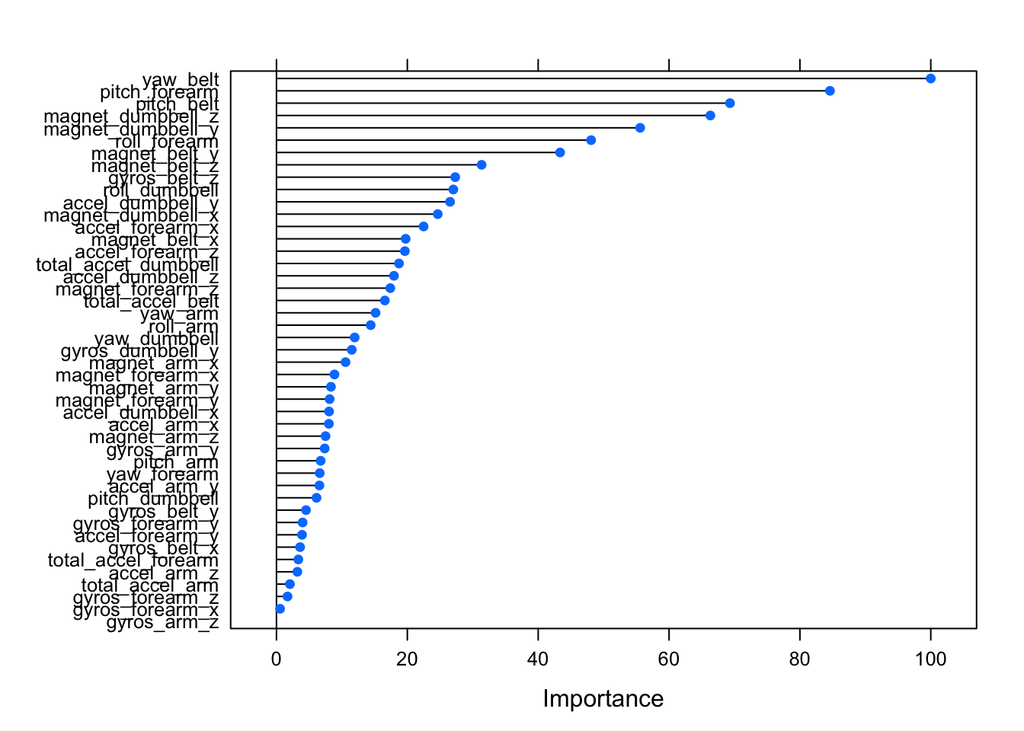

```r
## varImp -- Show
rfVarImp <- varImp(rfmodel)
plot(rfVarImp)
```

#### Predict the test samples

We used built prediction model to predict 20 different test cases.

```r
## predict assignment test result
finalPred <- predict(rfmodel,finalTest)

finalPred
```

```
##  [1] B A B A A E D B A A B C B A E E A B B B
## Levels: A B C D E
```